# lab

**Convex and Distributed Optimization Lab**  
**MSIAM — Université Grenoble Alpes — 2018/2019**  
**Lecturers: Jérôme Malick, Yassine Laguel, Sélim Chraibi**

**Author(s): Erwan Duvernay, Nathan Shourick**

```python
# Automatic reload of local libraries
%load_ext autoreload
%autoreload 2
%reload_ext autoreload
%matplotlib inline
```

```python
import numpy as np
import pandas as pd
import matplotlib.pyplot as plt
```

> **I. Introduction**  
> **II. The optimization problem**  
> **III. Implementing the solvers**  
> GD (Gradient descent))  
> SGD (Stochastic Gradient Descent))  
> SAGA (Stochastic Average Gradient "Amélioré"))  
> SVRG (Stochastic Variance Reduced Gradient))  
> Comparison  
> **IV. Regularization**  
> **V. Further development**

In this lab, you will implement optimization algorithms that you've studied in class and use them to fit a logistic regression classification model.

You will be implementing a simplified version of [`sklearn.linear_model.LogisticRegression`](https://scikit-learn.org/stable/modules/generated/sklearn.linear_model.LogisticRegression.html).

Part of the work has already been done for you (see the `\lib` folder), so you'll only have to implement the `##### TODO (i) #####` sections of the code. Whenever you complete such a section, we ask you to **copy it in this notebook**. We want you to **only send us a pdf or html export of this notebook** so we won't be able to see your work if it's not in this notebook.

Report in groups of 1 to 3 students.  
**Due date:** Monday, January 6, 2019 (before midnight).  
**Send to:** cdo.grenoble@gmail.com

# I. Introduction

We consider the [Student Performance](http://archive.ics.uci.edu/ml/datasets/Student+Performance) dataset. This dataset contains student demographic, social, school-related features, how many classes they've missed, etc.

The goal we give ourselves is to predict whether a student will pass (final grade > 12).

We denote $A \in \mathcal{M}_{n,d}(\mathbb{R})$ the feature matrix, containing $n$ samples with $d$ features, and $b \in \{-1,1\}^n$ the label vector where $-1$ encodes `fail` and $1$ encodes `pass`.

The data has already been preprocessed (yay less work for you 🎉). You can check `\lib\datasets.py` if you're curious, otherwise, you can just use the following to load your dataset:

```python
from lib.datasets import load_student_data

A_train, A_test, b_train, b_test = load_student_data('data/student-mat.csv', split=0.25)
```

As mentioned previously, you're going to implement a simplified version of [`sklearn.linear_model.LogisticRegression`](https://scikit-learn.org/stable/modules/generated/sklearn.linear_model.LogisticRegression.html). So let's first see what the finished product should look like.

**Question:**

- Import [sklearn.linear_model.LogisticRegression](https://scikit-learn.org/stable/modules/generated/sklearn.linear_model.LogisticRegression.html) .
- Create an instance of sklearn's logistic regression classifiers with SAGA as its solver.
- Fit the classifier on the training data and compute the score of the fitted model on the test set.

```python
from sklearn.linear_model import LogisticRegression as skl_log_reg

clf = skl_log_reg(solver='newton-cg')
score = clf.fit(A_train, b_train).score(A_test, b_test)
print("The score of the fitted model on the test set using sklearn is equal to {}.".format(score))
```

```
The score of the fitted model on the test set using sklearn is equal to 0.8787878787878788.
```

# II. The optimization problem

Logistic regression consists in finding the parameter $x \in \mathbb{R}^d$ that best fits: $$ b_i = \begin{cases} \phantom{-}1 \ \textrm{ if }\ \langle a_{i}, x\rangle \ge 0 \\ -1 \ \textrm{ if }\ \langle a_{i}, x\rangle < 0 \end{cases} $$ for all the samples $i$ of the training set (where $a_i$ is the $i^{th}$ line of $A$ and $b_i$ the $i^{th}$ element of $b$). To measure this fit, logistic regression chooses the following loss:

$$ \textrm{LogisticLoss}(b_i, \left\langle a_{i}, x\right\rangle ) = \log \left(1+\exp \left(-b_{i}\left\langle a_{i}, x\right\rangle\right)\right) $$

The corresponding optimization problem we will consider is the following:

Minimization of the empirical risk $f$ of the $L_2$-regularized logistic regression model, on the dataset $(A_{\textrm{train}},b_{\textrm{train}})$: $$ \begin{aligned} \textrm{min}_{x\in \mathbb{R}^d} \ f(x) \ &= \ \textrm{min}_{x\in \mathbb{R}^d} \ \frac{1}{n_{\textrm{train}}} \sum_{i=1}^{n_{\textrm{train}}} f_i(x) \\ &= \ \textrm{min}_{x\in \mathbb{R}^d}\frac{1}{n_{\textrm{train}}} \sum_{i=1}^{n_{\textrm{train}}} \textrm{LogisticLoss}(b_i, \left\langle a_{i}, x\right\rangle ) + \frac{l_2}{2}\|x\|^{2}_2, \end{aligned} $$ where $l_2 \ge 0$ is the $L_2$ regularization coefficient.

To simplify the notation, we'll stop indexing $A$, $b$ and $n$ with "$\textrm{train}$" in the following.

**Question:** $f$ is $\mu$-strongly convex.

- Give a lower bound on $\mu$.
- Complete **TODO (1)** in **\lib\linear_model.py**.

> **Answer:** Let us first prove that $\ell_i(\cdot) := \textrm{LogisticLoss}(b_i, \left\langle a_{i}, \cdot\right\rangle )$ is convex. We will compute its hessian and see that it is (symmetric) positive semi-definite, in which case the function is convex. \begin{aligned} \nabla \ell_i(x) &= \dfrac{- b_i a_i}{1 + \exp \left(b_{i}\left\langle a_{i}, x\right\rangle\right)}\\ \nabla^2 \ell_i(x) &= \dfrac{\exp \left(b_{i}\left\langle a_{i}, x\right\rangle\right)}{\left(1 + \exp \left(b_{i}\left\langle a_{i}, x\right\rangle\right)\right)^2} a_i a_i^T \end{aligned} since $b_i^2 = 1$. Thus, $$y^T \nabla^2 \ell_i(x) y = C y^T a_i a_i^T y = C \left(a_i^T y\right)^T \left(a_i^T y\right) = C \left(a_i^T y\right)^2 \geq 0.$$ since $a_i^T y \in \mathbb{R}$ and where we defined $C = \frac{\exp \left(b_{i}\left\langle a_{i}, x\right\rangle\right)}{\left(1 + \exp \left(b_{i}\left\langle a_{i}, x\right\rangle\right)\right)^2}$ which is strictly positive. $\ell_i$ is hence convex. Therefore, $$f - \frac{l_2}{2}\| \cdot \|^{2}_2 = \frac{1}{n} \sum_{i=1}^{n}\ell_i(\cdot)$$ is convex as sum of convex functions, which means that $f$ is at least $l_2$-strongly convex (because we cannot be sure, with these calculations, that $l_2$ is the larger constant for which $f$ is strongly convex). In other words, $\mu \geq l_2$.

**Question:** Denote $\lambda_{\max}$ the largest eigenvalue of the real symmetric matrix $AA^T$.

- Prove that $\lambda_{\max}(\nabla^2 f_i) \le \lambda_{\max}(\frac{a_i a_i^T}{4} + l_2 I_d)$
- Prove that $\lambda_{\max}(a_i a_i^T) \le \|a_i\|^2_2$

> **Answer:**
> - First, we have \begin{aligned} \nabla^{2}f_{i}(x) = \frac{\exp \left(b_{i}\left\langle a_{i}, x\right\rangle\right)}{\left(1 + \exp \left(b_{i}\left\langle a_{i}, x\right\rangle\right)\right)^2} a_i a_i^T + l_{2} I_{d} \end{aligned} We will then use two results:

>   Let $B$ a $d \times d$ real symmetric matrix and $\alpha \in \mathbb{R}$. Then, $\sup_{x \neq 0}\frac{x^T B x}{\|x\|^{2}_2} = \lambda_{\max}(B)$ and $\lambda_{\max}(B + \alpha I) = \lambda_{\max}(B) + \alpha$.
>   $B$ can be decomposed into $B = PDP^{T}$ where $P$ is an an orthogonal matrix whose columns are the eigenvectors of $B$ and $D$ a diagonal matrix whose entries are the eigenvalues $\lambda_k$. Let $x \neq 0$. Using the fact that $P^T$ preserves the norm once multiplied by a vector (by orthogonality) and setting $y = P^T x$, we have: \begin{aligned} \frac{x^T B x}{\|x\|_2^2} = \frac{(P^T x)^T D (P^T x)}{\|x\|_2^2} = \frac{y^T D y}{\|y\|_2^2} = \frac{\sum_{k=1}^{d} \lambda_{k} y_{k}^{2}}{\|y\|_2^2} \leq \frac{\sum_{k=1}^{d} \lambda_{\max} y_{k}^{2}}{\|y\|_2^2} = \lambda_{\max} \end{aligned} Thus, $\sup_{x \neq 0}\frac{x^T B x}{\|x\|_2^2} \leq \lambda_{\max}(B)$. Now, let $x \neq 0$ be the eigenvector of $B$ associated with the largest eigenvalue $\lambda_{\max}(B)$, then $\frac{x^T B x}{\|x\|^{2}_2} = \lambda_{\max}(B)$ so $ \lambda_{\max}(B) \leq \sup_{x \neq 0}\frac{x^T B x}{\|x\|^{2}_2}$.
>   We have $$B + \alpha I = PDP^{T} + \alpha I = PDP^{T} + P\alpha IP^{T} = P(D + \alpha I)P^{T}.$$ Therefore, for any $k = 1, \ldots, d$, $\lambda_k + \alpha$ is an eigenvalue of $B+\alpha I$. Since $B+\alpha I$ cannot have more than $d$ eigenvalues, its eigenvalues are exactly under the form $\lambda_k + \alpha$, $k = 1, \ldots, d$. Hence, since $\lambda_{\max}(B) \geq \lambda_k$ for all $k$, $\lambda_{\max}(B + \alpha I) = \lambda_{\max}(B) + \alpha$.

>   For any real $t$, $\dfrac{e^{t}}{(1+e^{t})^{2}} \leq \frac{1}{4}$.  
>   Indeed, \begin{aligned} \frac{e^{t}}{(1+e^{t})^{2}} = \frac{e^{t}}{1+2e^{t}+e^{2t}} = \frac{1}{e^{-t}+2+e^{t}} = \frac{1}{2}\frac{1}{\frac{e^{-t}+e^{t}}{2}+1} = \frac{1}{2}\frac{1}{\cosh(t) + 1} \leq \frac{1}{4} \end{aligned} since $\cosh(t) \geq 1$.

>   By the second result, $C = \frac{\exp \left(b_{i}\left\langle a_{i}, x\right\rangle\right)}{\left(1 + \exp \left(b_{i}\left\langle a_{i}, x\right\rangle\right)\right)^2} \leq \frac{1}{4}$. Therefore $\sup_{v \neq 0}\frac{v^T (C a_i a_i^T) v}{\|v\|^2_2} \leq \sup_{v \neq 0}\frac{v^T (\frac{1}{4} a_i a_i^T) v}{\|v\|^2_2}$.  
>   Then, by the first result, \begin{aligned} \lambda_{\max}(\nabla^{2}f_{i}(x)) &= \lambda_{\max}(C a_i a_i^T + l_{2} I_{d}) = \lambda_{\max}(Ca_i a_i^T) + l_{2} = \sup_{v \neq 0}\frac{v^T (C a_i a_i^T) v}{\|v\|^2_2} + l_{2}\\ &\leq \sup_{v \neq 0}\frac{v^T (\frac{1}{4} a_i a_i^T) v}{\|v\|^2_2} + l_{2} = \lambda_{\max}(\frac{a_i a_i^T}{4}) + l_{2} = \lambda_{\max}(\frac{a_i a_i^T}{4} + l_{2} I_{d}) \end{aligned}
> - Let $x \neq 0$ be the eigenvector of $a_i a_i^T$ associated with the largest eigenvalue $\lambda_{\max}(a_i a_i^T)$, i.e. $a_i a_i^T x = \lambda_{\max}(a_i a_i^T)x$. Then \begin{aligned} x^T a_i a_i^T x &= \lambda_{\max}(a_i a_i^T)\| x \|^{2}_2\\ \iff \left(a_i^T x\right)^2 &= \lambda_{\max}(a_i a_i^T)\| x \|^{2}_2\\ \underset{x \neq 0}{\iff} \dfrac{\left(a_i^T x\right)^2}{\| x \|^{2}_2} &= \lambda_{\max}(a_i a_i^T) \end{aligned} Applying Cauchy-Schwarz to the last equation leads to $$\lambda_{\max}(a_i a_i^T) \leq \dfrac{\| a_i \|^{2}_2 \| x \|^{2}_2}{\| x \|^{2}_2} = \| a_i \|^{2}_2$$ Actually, we have equality. Indeed $$ \left(a_i a_i^T\right)a_i = a_i \left(a_i^T a_i\right) = \| a_i \|^{2}_2 a_i $$ which means that $\| a_i \|^{2}_2$ is actually an eigenvalue of $a_i^T a_i$ associated with the eigenvector $a_i$. Therefore $\| a_i \|^{2}_2 \leq \lambda_{\max}(a_i a_i^T)$, by definition. Using the previous result leads to $$\lambda_{\max}(a_i a_i^T) = \| a_i \|^{2}_2.$$

A consequence of these results is that the $f_i$s and $f$ are all $L$-smooth with $L \le \frac{\max_i\|a_i\|^2_2}{4} + l_2$ and we can therefore use the following value in our implementation:

```
L = 0.25 * max(np.linalg.norm(A,2,axis=1))**2 + self.l2
```

# III. Implementing the solvers

To implement gradient methods, we need an oracle that will compute both batch gradients $\nabla f$ and partial gradients $\nabla f_i$.

**Question:** In the code below, $\nabla f$ has already been implemented.

- Complete **TODO (2)** bellow.
- Add your code to **\lib\linear_model.py**.

```python
def grad(x, i=None):
    '''
    Gradient of the objective function at x.
    If no i is given, grad should return the batch gradient.
    Otherwise, it should return the partial gradient associated the the datapoint (A[i], b[i]).
    '''

    if i is None: # return batch gradient
        output = -b/(1 + np.exp(b*np.dot(A, x)))
        output = sum(np.diag(output))/n @ A
        output += self.l2*x
    else: # return partial gradient associated the datapoint (A[i], b[i])
        output = - b[i] / (1 + np.exp(b[i] * np.dot(A[i][0], x))) * A[i][0]
        output += self.l2 * x

    return output
```

# GD (Gradient descent)

At iteration k of the GD algorithm, the following update is executed:

$$ x_{k+1} \leftarrow x_{k} - \gamma\nabla f(x_k) $$

**Question:**

- What stepsize $\gamma$ ensures the convergence of this algorithm and under what assumptions?
- Complete **TODO (3)** and **TODO (4)**
- Add your code to **\lib\solvers.py**.

> **Answer:** If $f$ is $L$-smooth (i.e. if $f$ is of class $C^1$ and $\nabla f$ is $L$-Lipschitz) then $\gamma \in \left(0, \frac{2}{L}\right)$ ensures the convergence of this algorithm. In practice, one takes $\gamma = \frac{1}{L}$.

```python
def GD(x0, grad, max_iter, n, L, mu):
    '''
    Parameters
    ----------
    x0: array, shape (nb_features,)
        Initialisation of the solver
    grad: function
        Gradient of the objective function
    max_iter: int
        Number of iterations (i.e. number of descent steps). Note that for GD or SVRG,
        one iteration is one epoch i.e, one pass through the data, while for SGD, SAG and SAGA,
        one iteration uses only one data point.
    n: int
        Dataset size
    L: float
        Smoothness constant of the objective function
    mu: float
        Strong convexity constant of the objective function

    Returns
    -------
    x: array, shape (nb_features,)
        final iterate of the solver
    x_tab: array, shape (nb_features, max_iter)
        table of all the iterates
    '''
    stepsize  = 1.0 / L
    x         = x0
    x_tab     = np.copy(x)

    for k in range(max_iter):
        x    -= stepsize * grad(x)
        x_tab = np.vstack((x_tab, x))

    return x, x_tab
```

**Question:** Run the code below to test your code.

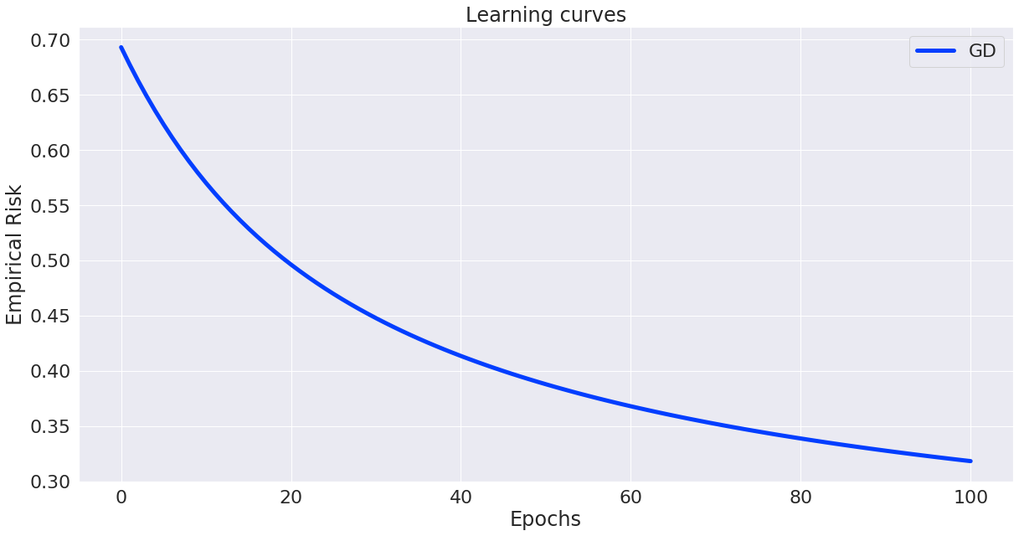

```
The score is 0.898989898989899.
```

```python
from lib.linear_model import LogisticRegression
from lib.visuals import learning_curve

clf_gd = LogisticRegression(solver='gd', l2=0.01, max_iter=100)
clf_gd.fit(A_train, b_train)

learning_curve(GD=clf_gd)

print("The score is {}.".format(clf_gd.score(A_test, b_test)))
```

# SGD (Stochastic Gradient Descent)

At iteration k of the SGD algorithm, the following update is executed:

$$ \begin{cases} i \textrm{ chosen randomly in } \{1...n\}\\ x_{k+1} \leftarrow x_{k} - \gamma_k \nabla f_i(x_k) \\ \end{cases} $$

**Question:**

- What stepsize $\gamma_k$ ensures the convergence of this algorithm and under what assumptions?
- Complete **TODO (5)**
- Add your code to **\lib\solvers.py**.

> **Answer:** The convergence of the algorithm is ensured whenever $f$ is strongly convex, the $f_i$ are convex and $L$-smooth and the stepsize $\gamma_k$ decreases and satisfies $\sum_{k=1}^{+\infty}\gamma_k^{2} < +\infty$ and $\sum_{k=1}^{+\infty}\gamma_k = +\infty$. $\gamma_k = \frac{1}{k}$ works but one prefers to use $\gamma_k = \frac{\gamma_0}{(1 + \frac{k}{k_0})^\alpha}$ in practice, where $\alpha \approx 0.6$.

```python
def SGD(x0, grad, prox, max_iter, n, L, mu):
    x        = x0
    x_tab    = np.copy(x)

    for k in range(max_iter):
        stepsize   = 1 / (k + 1)
        rand_index = np.random.randint(0, n-1, 1)
        x         -= stepsize * grad(x, rand_index)

        if k%n == 0: # each completed epoch
            x_tab  = np.vstack((x_tab, x))

    return x, x_tab
```

**Question:** Run the code below to test your code.

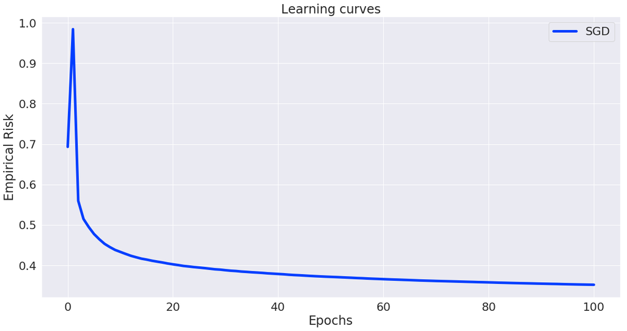

```python
clf_sgd = LogisticRegression(solver='sgd', l2=0.01, max_iter=100*len(b_train))
clf_sgd.fit(A_train, b_train)

learning_curve(SGD=clf_sgd)
```

# SAGA (Stochastic Average Gradient "Amélioré")

SAGA starts by computing a single batch gradient, then at iteration k, the following update is executed:

$$ \begin{cases} i \textrm{ chosen randomly in } \{1...n\}\\ x_{k+1} \leftarrow x_{k} - \gamma_k\big(\nabla f_i(x_k) - \alpha_i + \bar{\alpha}\big) \\ \alpha_i \leftarrow \nabla f_i(x) \end{cases} $$

where $(\alpha_j)_{j=1}^n$ are gradients evaluated at previous iterates and $\bar{\alpha}=\frac{1}{n}\sum^n_{j=1}\alpha_j$.

**Question:**

- What stepsize $\gamma_k$ ensures the convergence of this algorithm and under what assumptions?
- Complete **TODO (6)**
- Add your code to **\lib\solvers.py**.

> **Answer:** The stepsize $\gamma_k$ is usually constant, thus simply denoted $\gamma$. If each $f_i$ is $L$-smooth and $\mu$-strongly convex (this last assumption could be relaxed) then choosing $\gamma = \frac{1}{2(\mu n + L)}$ ensures the convergence of this algorithm.

```python
def SAGA(x0, grad, prox, max_iter, n, L, mu):
    stepsize  = 1.0 / (2.0 * (mu * n + L))
    x         = x0
    x_tab     = np.copy(x)
    # past gradients are initialized with x0, i.e. p_i,0 = x0 for all i
    # the n x0 are stacked vertically
    past_grad = np.tile(np.copy(x), (n, 1))

    for k in range(max_iter):
        rand_index = np.random.randint(0, n-1, 1)
        prev_grad  = past_grad[rand_index][0]
        past_grad  = np.array(list(map(lambda i: grad(x, i), range(n))))

        x         -= stepsize * (grad(x, rand_index) - prev_grad + np.mean(past_grad, axis=0))

        if k%n == 0: # each completed epoch
            x_tab = np.vstack((x_tab, x))

    return x, x_tab
```

**Question:** Run the code below to test your code.

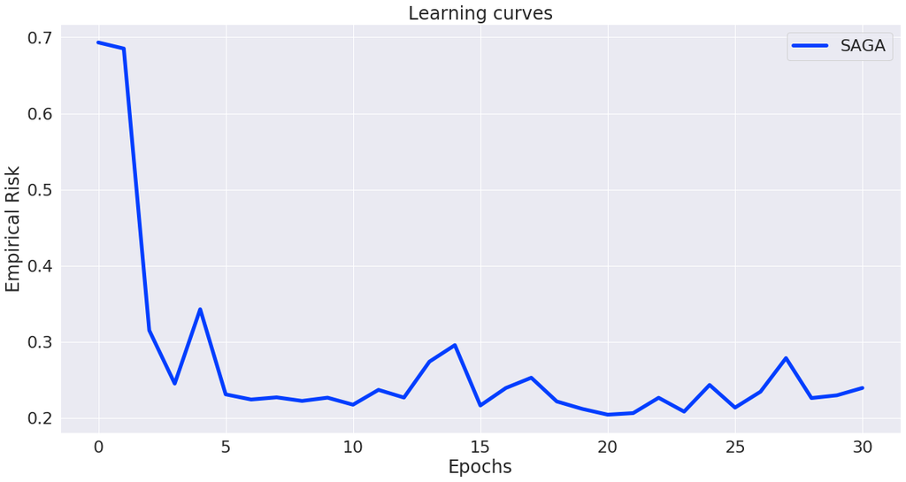

```
The score is 0.8686868686868687.
```

```python
clf_saga = LogisticRegression(solver='saga', l2=0.01, max_iter=30*len(b_train))
clf_saga.fit(A_train, b_train)

learning_curve(SAGA=clf_saga)

print("The score is {}.".format(clf_saga.score(A_test, b_test)))
```

# SVRG (Stochastic Variance Reduced Gradient)

At iteration k of the SVRG algorithm, we perform the following:

$$ \begin{cases} \textrm{Compute the batch gradient } \nabla f(x_k)\\ \textrm{Initialise }y_0 = x_k\\ \textrm{for m in 0...M-1: } \begin{cases} i \textrm{ chosen randomly in } \{1...n\} \\ y_{m+1} \leftarrow y_{m} - \gamma_k\big(\nabla f_i(y_m) - \nabla f_i(x_k) + \nabla f(x_k)) \end{cases}\\ x_{k+1} \leftarrow y_{M} \end{cases} $$

**Question:**

- What stepsize $\gamma_k$ ensures the convergence of this algorithm and under what assumptions?
- Complete **TODO (7)**
- Add your code to **\lib\solvers.py**.

```python
def SVRG(x0, grad, prox, max_iter, n, L, mu):
    stepsize   = 1.0 / L
    x          = x0
    x_tab      = np.copy(x)
    M          = 50

    for k in range(max_iter):
        batch_gradient = grad(x)

        y = np.copy(x)
        for m in range(M):
            rand_index = np.random.randint(0, n-1, 1)
            y  -= stepsize * (grad(y, rand_index) - grad(x, rand_index) + batch_gradient)

        x = y
        x_tab = np.vstack((x_tab, x))

    return x, x_tab
```

**Question:** Run the code below to test your code.

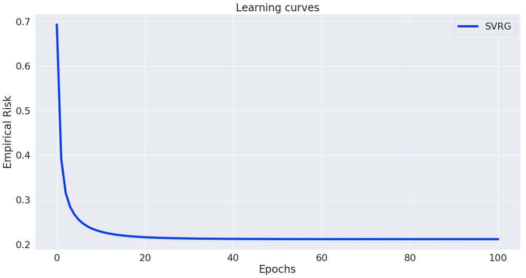

```python
clf_svrg = LogisticRegression(solver='svrg', l2=0.01, max_iter=100)
clf_svrg.fit(A_train, b_train)

learning_curve(SVRG=clf_svrg)
```

# Comparison

**Question:** Run the code below to compare all the methods you've implemented.

```python
epochs = 50
n = len(b_train)

clf_gd   = LogisticRegression(solver='gd', l2=0.01, max_iter=epochs)
clf_sgd  = LogisticRegression(solver='sgd', l2=0.01, max_iter=epochs*n)
clf_saga = LogisticRegression(solver='saga', l2=0.01, max_iter=epochs*n)
clf_svrg = LogisticRegression(solver='svrg', l2=0.01, max_iter=epochs)

clf_gd.fit(A_train, b_train)
clf_sgd.fit(A_train, b_train)
clf_saga.fit(A_train, b_train)
clf_svrg.fit(A_train, b_train)
```

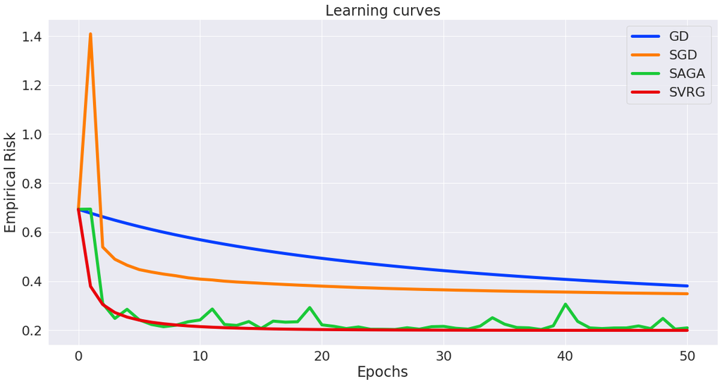

```
gd:	Accuracy on training set: 89.5%
	Accuracy on testing set:  81.8%
sgd:	Accuracy on training set: 86.5%
	Accuracy on testing set:  79.8%
saga:	Accuracy on training set: 95.3%
	Accuracy on testing set:  88.9%
svrg:	Accuracy on training set: 94.9%
	Accuracy on testing set:  88.9%
```

```python
learning_curve(GD=clf_gd, SGD=clf_sgd, SAGA=clf_saga, SVRG=clf_svrg)

for clf, name in zip([clf_gd, clf_sgd, clf_saga, clf_svrg], ['gd', 'sgd', 'saga', 'svrg']):
    print(name + ':' \
          + "\tAccuracy on training set: {0:0.1f}%".format(100*clf.score(A_train, b_train)))
    print("\tAccuracy on testing set:  {0:0.1f}%".format(100*clf.score(A_test, b_test)))
```

The SGD algorithm has a slightly better convergence rate than the GD algorithm has but is less accurate than it is. Nevertheless, they remain comparable. On the other hand, the SAGA and the SVRG algorithms are significantly better than them and are comparable, except that the SAGA takes much more time to stop, because it has to compute $n$ (costly) gradients at each iteration.

# IV. Regularization

**Question:**

- Rewrite the empirical risk minimization objective with both $L_1$ and $L_2$ regularization (with coefficients $l_1$ and $l_2$).
- Is this objective $\mu$-strongly convex, $L$-smooth, differentiable?
- Complete the **TODO (8)** to account for the new term in the objective.
- Add your code to **lib/linear_model.py**.

> **Answer:** The empirical risk minimization objective with both $L_1$ and $L_2$ regularization reads:

$$ f(x) = \frac{1}{n} \sum_{i=1}^{n} \textrm{LogisticLoss}(b_i, \left\langle a_{i}, x\right\rangle ) + \frac{l_2}{2}\|x\|^{2}_2 + l_1\|x\|_1 $$

where $l_1 \ge 0$ is the $L_1$ regularization coefficient and $l_2 \ge 0$ is the $L_2$ regularization coefficient.

> We already saw that $x \mapsto \textrm{LogisticLoss}(b_i, \left\langle a_{i}, x\right\rangle )$ is convex. It is also known that $\|\cdot\|_1$ is convex. Since the sum of convex functions is still convex, then $x \mapsto \frac{1}{n} \sum_{i=1}^{n} \textrm{LogisticLoss}(b_i, \left\langle a_{i}, x\right\rangle ) + l_1\|x\|_1$ is convex. Hence, by definition, as previously, $f$ is at least $l_2$-strongly convex. However, $\|\cdot\|_1$ is not differentiable (in $0$) so $f$ is not differentiable (in $0$) and thus cannot be $L$-smooth (because it should be $C^1$ otherwise).

```
self._empirical_risk = lambda x: sum(self._logistic_loss(A, b, x))/n \
                                 + self.l2/2.0 * np.linalg.norm(x,2)**2 \
                                 + self.l1 np.linalg.norm(x,1)
```

The minimization algorithms we've implemented have a slow rate of convergence for this new objective function. We will therefore use *proximal* variations of these algorithms.

**Question:** Using the $\textrm{prox}_{l_1 \|\cdot\|_1}$ operator, write down the $k^{th}$ step of proximal GD, proximal SGD, proximal SAGA, and proximal SVRG.

> **Answer:**
> - What changes in the $(k+1)^{th}$ step of the following gradient descent algorithms are:
>   - proximal GD: $$ x_{k+1} \leftarrow \textrm{prox}_{\gamma_k l_1 \|\cdot\|_1} \left(x_k - \gamma_k \nabla f(x_k)\right) $$
>   - proximal SGD: $$ \begin{cases} i_k \textrm{ chosen randomly in } \{1...n\}\\ x_{k+1} \leftarrow \textrm{prox}_{\gamma_k l_1 \|\cdot\|_1} \left(x_k - \gamma_k \nabla f_{i_{k}}(x_k)\right) \\ \end{cases} $$
>   - proximal SAGA: $$ \begin{cases} i_k \textrm{ chosen randomly in } \{1...n\}\\ x_{k+1} \leftarrow \textrm{prox}_{\gamma_k l_1 \|\cdot\|_1} \left(x_k - \gamma_k \left[\nabla f_{i_{k}}(x_k) - p_{i_{k}, k} + \frac{1}{n}\displaystyle\sum_{i=1}^{n}p_{i, k}\right]\right) \end{cases} $$
>   - proximal SVRD: $$ \begin{cases} \textrm{Compute the batch gradient } \nabla f(x_k)\\ \textrm{Initialise }y_0 = x_k\\ \textrm{for m in 0...M-1: } \begin{cases} i \textrm{ chosen randomly in } \{1...n\} \\ y_{m+1} \leftarrow \textrm{prox}_{\gamma_k l_1 \|\cdot\|_1} \left(y_m - \gamma_k \left[\nabla f_{i_{k}}(y_m) - \nabla f_{i_{k}}(x_k) + \nabla f(x_k) \right]\right)\\ \end{cases}\\ x_{k+1} \leftarrow y_{M} \end{cases} $$

**Question:**

- Give a closed-form expression of $\textrm{prox}_{l_1 \|\cdot\|_1}$
- Complete **TODO (9)** (note that you can access the $l_1$ coefficient using **self.l1**).
- Add your code to **\lib\linear_model.py**.

Let compute $p = \textrm{prox}_{l_1 |\cdot|}(x) = \arg\min_{y} (\underbrace{|y| + \frac{1}{2l_1}|y-x|^2}_{\phi(y)})$ for $x \in \mathbb{R}$: \begin{aligned} \phi(p) = \min_{y} \phi(y) &\iff 0 \in \partial \phi(p) \\ &\iff 0 \in \underbrace{\partial |\cdot|(p)}_\text{$sgn(p)$} + \frac{1}{l_1}(p-x) \\ &\iff x \in l_1 sgn(p) + p \end{aligned} So, $$ \begin{cases} \textrm{if}& p < 0 &\textrm{then}& x = -l_1 + p \\ \textrm{if}& p = 0 &\textrm{then}& x \in [-1, 1]\\ \textrm{if}& p > 0 &\textrm{then}& x = l_1 + p \end{cases} $$ Hence $$ \operatorname{prox}_{l_1 |\cdot|}(x) = \begin{cases} x + l_1 &\textrm{if}& x < -l_1 \\ 0 &\textrm{if}& x \in [-l_1, l_1]\\ x - l_1 &\textrm{if}& x > l_1 \end{cases} $$ Finally, for $x \in \mathbb{R}^d$, $$ \operatorname{prox}_{l_1 \|\cdot\|_1}(x) = \begin{pmatrix} \operatorname{prox}_{l_1 |\cdot|}(x_1) \\ \vdots \\ \operatorname{prox}_{l_1 |\cdot|}(x_d) \end{pmatrix} $$

```python
def prox(x, stepsize):
    k = stepsize * self.l1
    return np.array([y > k for y in x]) * (x - k) + np.array([y < -k for y in x]) * (x + k)
```

**Question:**

- Add **prox** to the attributes of the solvers (both in the call to **self.solver** in **/lib/linear_model.py** and in **/lib/solvers.py**) as follows:  
  solver(x0, grad, **prox**, self.max_iter, n, L, mu)
- Add a proximal step to all the algorithms in **/lib/solvers.py**.
- Paste one of these algorithms in the cell bellow.

```python
def SAGA(x0, grad, prox, max_iter, n, L, mu):
    stepsize  = 1.0 / (2.0 * (mu * n + L))
    x         = x0
    x_tab     = np.copy(x)
    # past gradients are initialized with x0, i.e. p_i,0 = x0 for all i
    # the n x0 are stacked vertically
    past_grad = np.tile(np.copy(x), (n, 1))

    for k in range(max_iter):
        rand_index = np.random.randint(0, n-1, 1)
        prev_grad  = past_grad[rand_index][0]
        past_grad  = np.array(list(map(lambda i: grad(x, i), range(n))))

        x          = prox(x - stepsize * (grad(x, rand_index) - prev_grad + np.mean(past_grad, axis=0)), stepsize)

        if k%n == 0: # each completed epoch
            x_tab = np.vstack((x_tab, x))

    return x, x_tab
```

**Question:** If your proximal gradient descent is correctly implemented, the following cell will plot the support of the solution for various values of $l_1$.

- Interpret the plot and explain what can $L_1$ regularization be used for.

> **Answer:** According to the plot, the bigger is $l_1$, the more null coordinates of x there are. $L_1$ acts like a Lasso Regression, it makes null a few coefficients that has to be removed from the model. It our case, these are weights that do not improve the model.

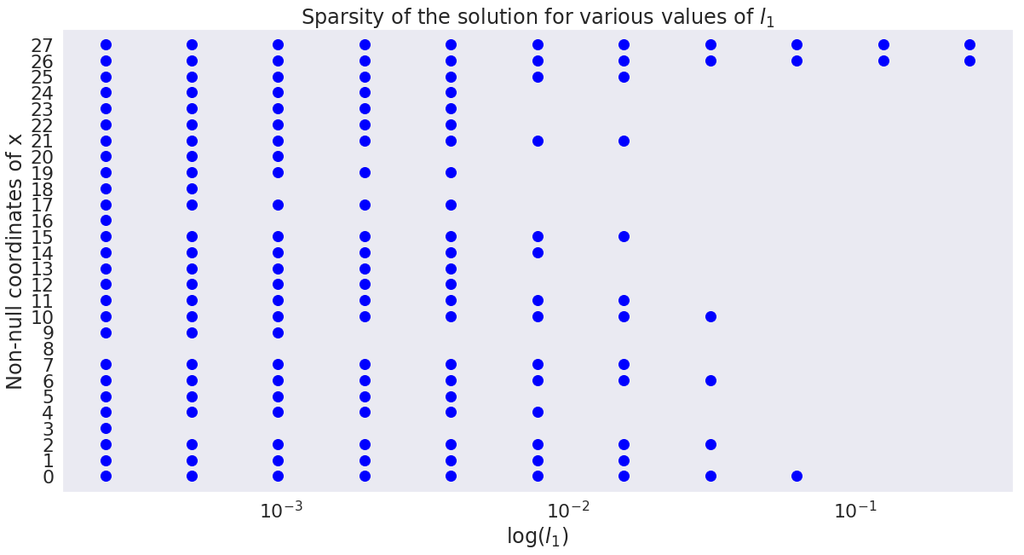

```python
from lib.linear_model import LogisticRegression
from lib.visuals import l1_regularization_plot

clf = lambda l1: LogisticRegression(solver='gd', l1=l1, l2=0.1, max_iter=1000)

l1_regularization_plot(clf, A_train, b_train)
```

We notice that the algorithm selects some coordinates as the other get to zero. The number of non-null coordinates decreases as $\lambda_1$ increases. They were selected as relevant for the machine learning task: the corresponding features are the most significant for the student success. The bigger $\lambda_1$ is, the less features are significant; we gain in accuracy. Here, the most significant features mainly are the period grades.

**Question:** The following cell will plot the value of the coordinates of the solution for various values of $l_2$.

- Interpret the plot and explain what can $L_2$ regularization be used for.

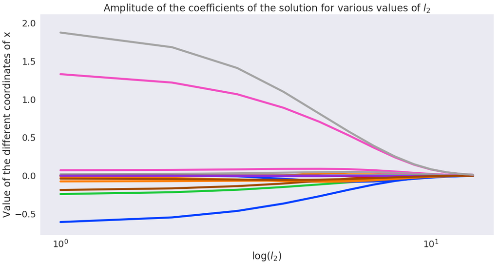

```python
from lib.visuals import l2_regularization_plot

clf = lambda l2: LogisticRegression(solver='gd', l1=0.01, l2=l2, max_iter=1000)

l2_regularization_plot(clf, A_train, b_train)
```

According to the plot, the bigger is $l_2$, the more the value space of the whole coordinates of x is smaller. $l_2$ acts like a Ridge Regression, a kind of shrinkage. It narrows the range of values the weights can take.

# V. Further development

We expect that you go beyond the lab's questions and that you develop certain aspects of your work, depending on your personal interests and skills, for instance:

- Implementations and numerical tests (further developments, more experiments, etc.)
- Applications in learning or statistics (interpretation of some results, other models, other datasets, etc.)
- Theoretical or mathematical questions (convergence proofs, convergence rates, advanced versions of an algorithm, theoretical analysis of special cases, etc.)

**Keyword ideas**: standard or stochastic Newton method, ADMM, continuation methods, tests on large scale datasets, intuition behind variance reduction, catalyst...

## Quasi-Newton with Wolfe line search: Broyden–Fletcher–Goldfarb–Shanno algorithm

According to the Zoutendijk theorem, choosing a stepsize of the iterative method that verifies the Wolfe conditions leads to the convergence of the BFGS algorithm. Let a function $f$, denoting $x_k$ the parameter, $d_k$ the descent direction $d_k^T \nabla f(x_k) < 0$ and $\gamma_k$ the stepsize at iteration $k$, the conditions are: $$ \begin{cases} \begin{aligned} &f(x_k + \gamma_k d_k) \leq f(x_k) + \alpha \gamma_k d_k^T \nabla f(x_k) \ \ \ &\alpha \in \left]0, 1\right[\\ &d_k^T \nabla f(x_k + \gamma_k d_k) \geq \beta d_k^T \nabla f(x_k) &\beta \in \left]\alpha, 1\right[ \end{aligned} \end{cases} $$

Here is the BFGS algorithm:

Initialise the vector $x_0$ and the matrix $W_0 \in \mathcal{S}_n^{++}(\mathbb{R})$, then repeat the following setps until the user-specified maximum number of iterations has been achieved:

1. Choose the direction $d_k = W_k \nabla f(x_k)$.
2. Perform a line search to find a stepsize $\gamma_k$ that verifies Wolfe conditions.
3. Update $x_{k+1} = x_k - \gamma_k d_k$.
4. Let $y_k = \nabla f(x_{k+1}) - \nabla f(x_k)$ and $s_k = x_{k+1}-x_{k}$.
5. Compute $W_{k+1} = W_k + \dfrac{(s_k^T y_k + y_k^T W_k y_k) (s_k s_k^T)}{(s_k^T y_k)^2} - \dfrac{W_k y_k s_k^T + s_k y_k^T W_k}{s_k^T y_k}$.

```python
from scipy.optimize import line_search

def wolfe_line_search(x, fun, grad, descent_direction):
    """
    Wolfe line search: give an optimal stepsize
    """
    res = line_search(fun, grad, x, descent_direction)
    return res[0]

def BFGS(x0, fun, grad, prox, max_iter, n, L, mu):
    x         = x0
    x_tab     = np.copy(x)
    W         = np.eye(x.shape[0])

    for k in range(max_iter):
        g = grad(x)
        d = np.dot(W, g)

        stepsize = wolfe_line_search(x, fun, grad, -d)
        if stepsize is None: # a suitable step size may be not found
            stepsize = 1.0 / L

        # update of the current iterate
        past_x = np.copy(x)
        x     -= stepsize * d
        x_tab  = np.vstack((x_tab, x))

        # update of the hessian approximation
        s   = x - past_x
        y   = grad(x) - g
        Wy  = np.dot(W, y)
        ys  = np.inner(y, s)
        W  -= (np.outer(s, Wy) + np.outer(Wy, s)) / ys
        W  += (ys + np.inner(y, Wy)) * np.outer(s, s) / ys ** 2

    return x, x_tab
```

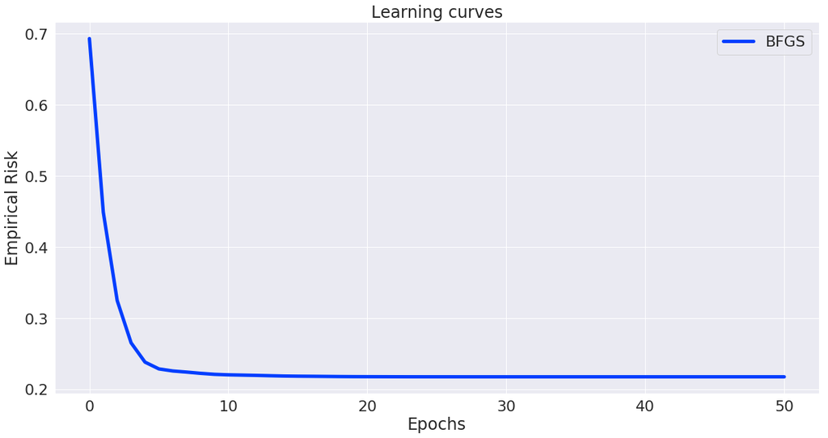

```
The score is 0.9292929292929293.
```

```python
from lib.linear_model import LogisticRegression
from lib.visuals import learning_curve

clf_bfgs = LogisticRegression(solver='bfgs', l2=0.01, max_iter=50)
clf_bfgs.fit(A_train, b_train)

learning_curve(BFGS=clf_bfgs)

print("The score is {}.".format(clf_bfgs.score(A_test, b_test)))
```

#### Comparison with the previous methods

```python
epochs = 50
n = len(b_train)

clf_gd   = LogisticRegression(solver='gd', l2=0.01, max_iter=epochs)
clf_sgd  = LogisticRegression(solver='sgd', l2=0.01, max_iter=epochs*n)
clf_saga = LogisticRegression(solver='saga', l2=0.01, max_iter=epochs*n)
clf_svrg = LogisticRegression(solver='svrg', l2=0.01, max_iter=epochs)
clf_bfgs = LogisticRegression(solver='bfgs', l2=0.01, max_iter=epochs)

clf_gd.fit(A_train, b_train)
clf_sgd.fit(A_train, b_train)
clf_saga.fit(A_train, b_train)
clf_svrg.fit(A_train, b_train)
clf_bfgs.fit(A_train, b_train)
```

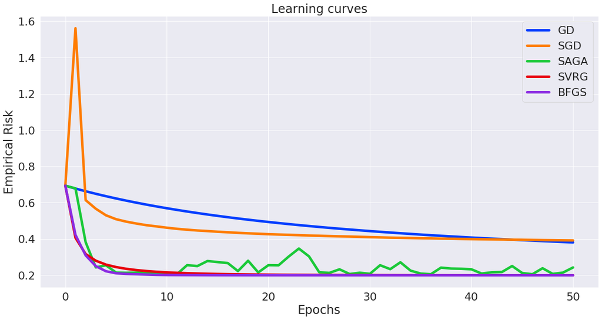

```
gd:	Accuracy on training set: 89.5%
	Accuracy on testing set:  81.8%
sgd:	Accuracy on training set: 84.8%
	Accuracy on testing set:  78.8%
saga:	Accuracy on training set: 92.9%
	Accuracy on testing set:  84.8%
svrg:	Accuracy on training set: 94.9%
	Accuracy on testing set:  88.9%
bfgs:	Accuracy on training set: 94.6%
	Accuracy on testing set:  88.9%
```

```python
learning_curve(GD=clf_gd, SGD=clf_sgd, SAGA=clf_saga, SVRG=clf_svrg, BFGS=clf_bfgs)

for clf, name in zip([clf_gd, clf_sgd, clf_saga, clf_svrg, clf_bfgs], ['gd', 'sgd', 'saga', 'svrg', 'bfgs']):
    print(name + ':' \
          + "\tAccuracy on training set: {0:0.1f}%".format(100*clf.score(A_train, b_train)))
    print("\tAccuracy on testing set:  {0:0.1f}%".format(100*clf.score(A_test, b_test)))
```

The BFGS algorithm is very satisfactory, accurate and fast. Note it is a second-order method, contrary to the other ones which are first-order methods.

## Analysis of the SGD algorithm

**Problem statement:** Solve $$\min_{x \in \mathbb{R}^d} f(x) = \min_{x \in \mathbb{R}^d} \frac{1}{n} \sum_{i = 1}^n f_i(x)$$ where the $f_i$ are convex and $L$-smooth functions and $f$ is a $\mu$-strongly convex function, thus admits a unique minimizer, denoted $x^*$. All these conditions are satisfied in the previous setting as it has been seen.

**Algorithm:** At iteration k, the following update is executed:

$$ \begin{cases} i \textrm{ chosen randomly in } \{1, \ldots, n\}\\ x_{k+1} \leftarrow x_{k} - \gamma_k \nabla f_i(x_k) \\ \end{cases} $$

**About convergence rate:**

To simplify the analysis of the algorithm, we actually look at a variant of SGD where the final output is the average of all the intermediate iterations. After T iterations, we look at $\bar{x}_T = \frac{1}{T} \sum_{k=0}^{T-1} x_k$. Looking at the average is not only a trick for the analysis, it has other theoretical advantages and can be seen as an online machine learning method for instance (used when it is impossible to train over the entire data set because of the far too high calculation cost). We present here a bound on the convergence rate of SGD, that is: $$ \mathbb{E}f(\bar{x}_T) - f(x^*) \leq \dfrac{2L}{T} \|x_0 - x^* \|_2^2 + \dfrac{4 \sigma^2}{\mu T} \ln \left( 1 + \dfrac{\mu T}{4L} \right) $$ where $T$ is the number of iterations. This theoretical analysis allows us to propose an alternative version for the SGD algorithm where the final output is the average of all the intermediate iterations and where the stepsize (learning rate) is explicitely given.

As in the course, we denote by $\mathcal{F}_k$ the information given up to time $k$. Finally, we denote by $\sigma^2 = \frac{1}{n} \sum_{i=1}^n \| \nabla f_i(x^*) \|_2^2$ the variance of the gradients at the optimum and we define $\varepsilon_k = \mathbb{E} \|x_k - x^* \|_2^2$, where we consider the expectation (and the coming others) with respect to the internal randomization of the algorithm.

First, let us prove that $$\varepsilon_{k+1} \leq \varepsilon_k - 2 \gamma_k(1 - \gamma_k L) \mathbb{E}[\nabla \langle f(x_k), x_k - x^* \rangle] + 2 \gamma_k^2 \sigma^2.$$

Let $i$ chosen randomly in $\{1, \ldots, n\}$. We have:

\begin{align*} \| x_{k+1} - x^* \|_2^2 &= \| (x_{k} - x^*) - \gamma_k \nabla f_i(x_k) \|_2^2\\ &= \| x_k - x^* \|_2^2 - 2\gamma_k \langle \nabla f_i(x_k), x_{k} - x^* \rangle + \gamma_k^2 \| \nabla f_i(x_k) \|_2^2\\ &\underset{(1)}{\leq} \| x_k - x^* \|_2^2 - 2\gamma_k \langle \nabla f_i(x_k), x_{k} - x^* \rangle + 2 \gamma_k^2 \| \nabla f_i(x^*) \|_2^2 + 2 \gamma_k^2 \| \nabla f_i(x_k) - \nabla f_i(x^*) \|_2^2\\ &\underset{(2)}{\leq} \| x_k - x^* \|_2^2 - 2\gamma_k \langle \nabla f_i(x_k), x_{k} - x^* \rangle + 2 \gamma_k^2 \| \nabla f_i(x^*) \|_2^2 + 2 L \gamma_k^2 \langle \nabla f_i(x_k) - \nabla f_i(x^*), x_{k} - x^* \rangle\\ \end{align*}

For $(1)$, we used the property $\| x \|^2 \leq 2 \| y \|^2 + 2 \| x - y \|^2$, which holds for any $x,y \in \mathbb{R}^d$ and for any norm on $\mathbb{R}^d$. Indeed, by the triangle inequality, we have $\| x \| \leq \| y \| + \| x - y \|$ and then squaring, the result is obvious using the inequality $(a+b)^2 \leq 2 a^2 + 2 b^2$ (which comes from $2 ab \leq a^2 + b^2$), for $a,b \in \mathbb{R}$. For $(2)$, we used the following not-so-obvious inequality which holds when a function $g$ is both convex and $L$-smooth: $$ \| \nabla g(x) - \nabla g(y) \|_2^2 \leq L \langle \nabla g(x) - \nabla g(y), x - y \rangle $$ whose proof can be found in the paper [Zhou, Xingyu. “On the Fenchel Duality between Strong Convexity and Lipschitz Continuous Gradient.” arXiv preprint arXiv:1803.06573 (2018).].

Now, by taking the expectation knowing $\mathcal{F}_k$, we get: \begin{aligned} \mathbb{E}[\|x_{k+1} - x^* \|_2^2 | \mathcal{F}_k] &\leq \| x_k - x^* \|_2^2 - 2\gamma_k \langle \mathbb{E}[\nabla f_i(x_k)], x_{k} - x^* \rangle + 2 \gamma_k^2 \mathbb{E} \| \nabla f_i(x^*) \|_2^2 + 2 L \gamma_k^2 \langle \mathbb{E}[\nabla f_i(x_k)] - \mathbb{E}[\nabla f_i(x^*)], x_{k} - x^* \rangle\\ &\leq \| x_k - x^* \|_2^2 - 2\gamma_k \langle \nabla f(x_k), x_{k} - x^* \rangle + 2 \gamma_k^2 \underbrace{\mathbb{E} \| \nabla f_i(x^*) \|_2^2}_{= \sigma^2} + 2 L \gamma_k^2 \langle \nabla f(x_k) - \underbrace{\nabla f(x^*)}_{= 0}, x_{k} - x^* \rangle\\ &\leq \| x_k - x^* \|_2^2 - 2\gamma_k \langle \nabla f(x_k), x_{k} - x^* \rangle + 2 \gamma_k^2 \sigma^2 + 2 L \gamma_k^2 \langle \nabla f(x_k), x_{k} - x^* \rangle \\ &\leq \| x_k - x^* \|_2^2 - 2\gamma_k (1 - \gamma_k L) \langle \nabla f(x_k), x_{k} - x^* \rangle + 2 \gamma_k^2 \sigma^2 \\ \end{aligned}

We retake the expectation and use the law of total expectation: $$ \mathbb{E}\|x_{k+1} - x^* \|_2^2 \leq \mathbb{E} \| x_k - x^* \|_2^2 - 2\gamma_k (1 - \gamma_k L) \mathbb{E}[\langle \nabla f(x_k), x_{k} - x^* \rangle] + 2 \gamma_k^2 \sigma^2 $$

Taking $$\gamma_k = \dfrac{1}{2L + \frac{\mu}{2}(k + 1)}$$ then $\gamma_k \leq 2 \gamma_k (1 - \gamma_k L)$ - having chosen $\gamma_k \leq \frac{1}{2L}$ would have been enough. Using the previous result, we obtain: \begin{aligned} \varepsilon_{k+1} &\leq \varepsilon_k - \gamma_k \mathbb{E}[\langle \nabla f(x_k), x_{k} - x^* \rangle] + 2 \gamma_k^2 \sigma^2\\ &\underset{(3)}{\leq} \varepsilon_k - \gamma_k \mathbb{E}[f(x_k) - f(x^*) + \dfrac{\mu}{2} \| x_k - x^* \|_2^2] + 2 \gamma_k^2 \sigma^2\\ &\leq \varepsilon_k - \gamma_k \left(\mathbb{E}[f(x_k) - f(x^*)] + \dfrac{\mu}{2} \varepsilon_k \right) + 2 \gamma_k^2 \sigma^2\\ \end{aligned}

For $(3)$, we used the following property coming from the strong convexity of $f$: $$ f(y) \geq f(x) + \langle \nabla f(x), y - x \rangle + \dfrac{\mu}{2} \| y - x \|_2^2 $$

By rearranging, we end up with: \begin{aligned} \mathbb{E}f(x_k) - f(x^*) &\leq -\dfrac{1}{\gamma_k} \varepsilon_{k+1} + \left( \dfrac{1}{\gamma_k} - \dfrac{\mu}{2} \right) \varepsilon_k + 2 \gamma_k \sigma^2\\ &\leq - (2L + \dfrac{\mu}{2}(k+1)) \varepsilon_{k+1} + \left( 2L - \dfrac{\mu}{2} k \right) \varepsilon_k + 2 \gamma_k \sigma^2\\ \end{aligned}

Then follows the final result: \begin{aligned} \mathbb{E}f(\bar{x}_T) - f(x^*) &\leq \dfrac{1}{T} \sum_{k = 0}^{T-1} \mathbb{E} f(x_k) - f(x^*)\\ &\leq \dfrac{2L}{T} \varepsilon_0 + \dfrac{2 \sigma^2}{T} \sum_{k = 0}^{T-1} \gamma_k\\ &\leq \dfrac{2L}{T} \|x_0 - x^* \|_2^2 + \dfrac{4 \sigma^2}{\mu T} \ln \left( 1 + \dfrac{\mu T}{4L} \right) \end{aligned} where we used the convexity of $f$, a telescoping sum and bounded from above $\sum_{k = 0}^{T-1} \gamma_k$ by $\dfrac{1}{2L} \displaystyle \int_0^T \dfrac{\mathrm{d}t}{1 + \frac{\mu t}{4L}}$.